# MATH5741M: Statistical Theory and Methods

Benjamin Thorpe

2021-09-26

Benjamin Thorpe (b.thorpe@leeds.ac.uk)  
Sunday September 26, 2021

# 1 Introduction

This module will introduce you to statistical ideas and tools that will be necessary for future modules and possibly for your final dissertation. **To succeed in this module**, I expect you to do the following:

- Attempt to fill any gaps in your knowledge of the mathematics required. In this chapter I will make some suggestions about how you might do that.
- Try to attend **all** lectures and practicals. Having everything recorded is not an excuse to skip lectures or to watch them later, except in cases where that is completely unavoidable. Students who succeed on this module are usually those who make an effort to attend and do not procrastinate.
- Complete the homework assignments.
- Take the coursework seriously **from the beginning**, not just on the week of the deadline. This coursework counts for $20\%$ of your module mark. It should also be treated as part of your learning (not just assessment) and as a chance to **discuss ideas with other students**. It is by far the best preparation that this module provides for real-life statistical work and it will also help you to improve your R skills.

The module is self contained, so there is **no required extra reading**. If you want to do some extra reading, you are encouraged to find books that meet your own specific needs. There are many books that cover the same topics as this module.

- The book that matches this module most closely is probably [Probability and Statistics, by Degroot and Schervish](https://leeds.primo.exlibrisgroup.com/permalink/44LEE_INST/1kmht9a/alma991011836849705181), which is available in the library.
- A very close approximation of the book by Degroot and Schervish, available online, is [Probability and Statistical Inference, by Hogg, Tanis and Zimmerman](https://leeds.primo.exlibrisgroup.com/permalink/44LEE_INST/13rlbcs/alma991002998499705181), which has plenty of examples and exercises.
- For more on probability and random variables, the book [Probability: an introduction, by Grimmett and Welsh](https://leeds.primo.exlibrisgroup.com/permalink/44LEE_INST/1fj430b/cdi_askewsholts_vlebooks_9780191019937), is available online through the library.

## 1.1 Statistics and data science

“I would claim that the unique strength of the statistics discipline is the extent of its relevance to the whole of the natural and social sciences.” - [Peter Diggle, Statistics: a data science for the 21st century](https://rss.onlinelibrary.wiley.com/doi/10.1111/rssa.12132)

Statistical methods are applied in many fields, both in academia and in industry. In my own short career as a statistician, I have worked on projects in engineering, e-commerce, education research, medicine and health economics. I have taught statistics to students of mathematics, medicine, computer science, physics, chemistry, biology and finance. I am currently working with data on criminology and on water poverty in Africa. My research and teaching experiences have made clear to me the real-life importance of statistics.

But how is statistics related to data science? Do they overlap? Are they just the same subject under different names? Are they in competition with each other? Is one just a subset of the other? These questions have been discussed by statisticians who are much more experienced than I am:

“There’s so much that goes on with data that is about computing, not statistics. I do think it would be fair to consider statistics as a subset of data science. The tech industry has always had to deal with databases and coding; that stuff is a necessity. The statistical part of data science is more of an option.” - [Andrew Gelman, Columbia University](https://statmodeling.stat.columbia.edu/2013/11/14/statistics-least-important-part-data-science/)

“Statistics can do all sorts of things. I love statistics! But it’s not the most important part of data science, or even close.” - [Andrew Gelman, Columbia University](https://statmodeling.stat.columbia.edu/2013/11/14/statistics-least-important-part-data-science/)

“If data science is a close relation of statistics, its increasing popularity must surely present us [statisticians] with an opportunity. We should embrace data science, proudly assert what we can offer it and humbly acknowledge what we can learn from it. What can we offer? Crucially, we can assert that uncertainty is ubiquitous and that probability is the correct way to deal with uncertainty. We understand the uncertainty in our data by building stochastic models, and in our conclusions by probabilistic inference.” - [Peter Diggle, Statistics: a data science for the 21st century](https://rss.onlinelibrary.wiley.com/doi/10.1111/rssa.12132)

If your main interest is data science, Andrew Gelman’s comments might reassure you that statistics can be safely avoided. This might be true, but it does not mean that statistics cannot be very useful in data science, as it is in many other sciences. And Gelman’s opinion that statistics is optional will not necessarily be prevalent among employers in data science.

Peter Diggle’s comment is much more optimistic. It suggests that there is potential for statisticians, and for data scientists with a strong knowledge of statistics, to contribute to data science. In particular, he highlights the use of statistical models and inference to handle uncertainty. For us, this is very encouraging, because modelling and inference will be the main focus of this module. I fully agree with Peter Diggle, and I strongly believe that this module will be extremely helpful to anyone who hopes for a career in data science, or in any other science where conclusions must be made based on either observational or experimental data.

## 1.2 Mathematical prerequisites

### 1.2.1 Sequences

You won’t need a deep understanding of concepts such as convergence of sequences, but you should at least make sure that you are comfortable with the notation for finite or infinite sequences of numbers:
$$x_{1}, x_{2}, x_{3}, \ldots$$
where each $x_{i}$, for $i = 1,2,3,\ldots$, is some number indexed by $i$. We will very often use the notation
$$\sum_{i = 1}^{n} x_{i} = x_{1} + x_{2} + \ldots + x_{n} \quad\text{ and }\quad \prod_{i = 1}^{n} x_{i} = x_{1} \times x_{2} \times \ldots \times x_{n}$$
to denote the sum and product (respectively) of the first $n$ terms of our sequence. We will sometimes write
$$x_i \rightarrow L \;\text{ as }\; i\rightarrow \infty,$$
which means that our sequence “tends to” (or “converges to” or “approaches”) the number $L$ when we make $i$ extremely large. We say that $L$ is the **limit** of the sequence.

### 1.2.2 Sets

We will sometimes define new sets as combinations of two existing sets $A$ and $B$:

- The **intersection** is $A \cap B = \left\{x \;:\; x \in A \text{ and } x \in B \right\}$.
- The **union** is $A \cup B = \left\{x \;:\; x \in A \text{ or } x \in B \right\}$.
- The **difference** is $A \setminus B = \left\{x \;:\; x \in A \text{ and } x \notin B \right\}$, where $\notin$ means “not in”.

For example, please check that you understand why
$$(1, 4) \cup (3, 100) = (1, 100)\;\;\;\text{and}\;\;\;(1, 4] \cap (3, 100] = (3, 4].$$
The notation for intersections, unions and differences doesn’t just apply to sets of numbers. We will often consider sets of objects, sets of people, and so on.

### 1.2.3 Functions

To denote a function or map from a set $A$ to a set $B$, we will write
$$f:A\rightarrow B,$$
which we read as “$f$ **maps** each element of $A$ to an element of $B$”. For each $x \in A$, we denote by $f(x)$ the corresponding element of $B$. The important feature of a function is that it maps each element of the **domain** $A$ to exactly one element of the **codomain** $B$. We will sometimes use the “maps to” notation such that, for example, we would write the function $f(x) = x^2$ as
$$f: x \mapsto x^2.$$
We will denote the **inverse** of $f$ by $f^{-1}$. This is the function $f^{-1}:B \rightarrow A$ such that if $f:a \mapsto b$ then $f^{-1}:b\mapsto a$. In other words, such that $f^{-1}(f(x)) = x$ for all $x \in A$. For example, the exponential function
$$\exp(x) = e^x$$
(where $e = 2.718282\ldots$) has inverse $\log(x)$, called the **natural logarithm**, such that
$$\log(\exp(x)) = x = \exp(\log(x)).$$
Unless stated otherwise, any logarithm in this module is assumed to be a natural (base $e$) logarithm (often written as $ln(x)$ in books and in other modules). You are expected to be familiar with the basic rules for logarithms and exponents. For example, $\log(ab) = \log a + \log b$, $\log a^b = b\log a$, $\exp(a + b) = \exp(a)\exp(b)$ and $\exp(ab) = \exp(a)^b$.

### 1.2.4 Calculus

I do expect you to be able to differentiate and integrate simple functions (e.g. polynomials, logarithms and the exponential function). I expect you to be able to differentiate using both the **product rule**,
$$\frac{d}{dx} \,\bigg( f(x)\times g(x) \bigg) \;\; =\;\; \frac{df}{dx}(x)\times g(x) \;\;+ \;\; f(x)\times \frac{dg}{dx}(x),$$
and the **chain rule**,
$$\frac{d}{dx}f\bigg(g(x)\bigg) \;\;=\;\; \frac{dg}{dx}(x)\times \frac{df}{dx}\bigg(g(x)\bigg).$$
We will sometimes integrate products of functions using **integration by parts**,
$$\int f(x)\times g(x)\, dx \;\;=\;\; f(x) \times \int g(x)\,dx \;\;-\;\; \int\left(\frac{df}{dx}(x) \times \int g(x)\,dx\right)dx.$$
I will use integration by parts in lectures, but I will not expect you to use it yourself. You will not be expected to evaluate difficult integrals, for example integrals that require the use of partial fractions. You don’t need to know how to integrate/differentiate trigonometric functions.

Recent students have found https://www.wolframalpha.com/problem-generator/ and http://tutorial.math.lamar.edu/Problems/CalcI/CalcI.aspx useful. To get the most out of either of these links, focus on differentiation of functions that involve polynomials, exponential functions and natural logarithms. Try some questions that involve the product rule or chain rule. Don’t bother with questions that require the quotient rule or differentiation of trigonometric functions.

Generally, for revision of basic maths (around the standard of first-year A-level modules, including calculus), you shouldn’t have much difficulty finding books at an appropriate level in the library or in any bookshop. For example, the library provides free access to [Mathematics for Engineers and Technologists, by Fox and Bolton (chapters 1 and 3 are most relevant for us)](https://www.sciencedirect.com/book/9780750655446/mathematics-for-engineers-and-technologists), and also to [Probability and Statistics: A Course for Physicists and Engineers, by Mathai and Haubold (chapter 1 is most relevant)](https://www.degruyter.com/view/title/534115). Both books cover the basic maths that we will need, as well as some statistics and probability.

## 1.3 Probability

Before we can do any statistics, we need to understand some probability. Most of the ideas here will be intuitively obvious, but we should make the notation and definitions as clear as possible. We will achieve this through an example. Throughout this module, motivating examples will be used to introduce any new theory.

**Example 1.1 (prevalence of a disease)** In a population of people, the prevalence of a disease is the proportion of people in the population who have that disease. Suppose that the prevalence of a specific disease is as summarised in Figure 1.2.

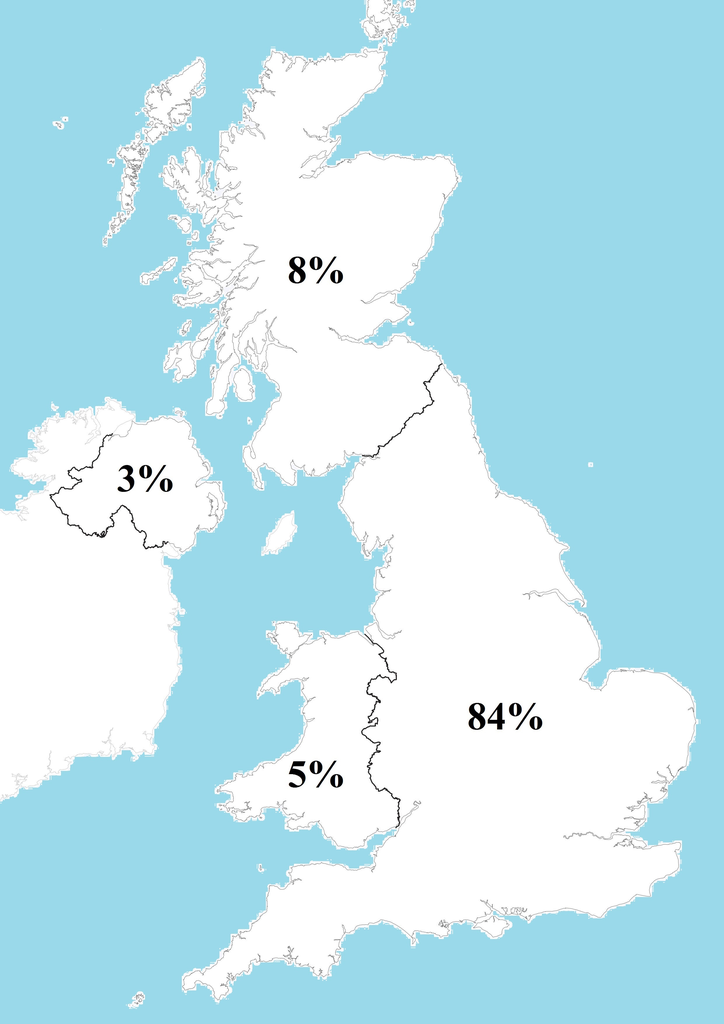

Figure 1.1: Proportion of the UK population in England, Scotland, Wales, and Northern Ireland ($84\%$, $8\%$, $5\%$ and $3\%$, respectively).

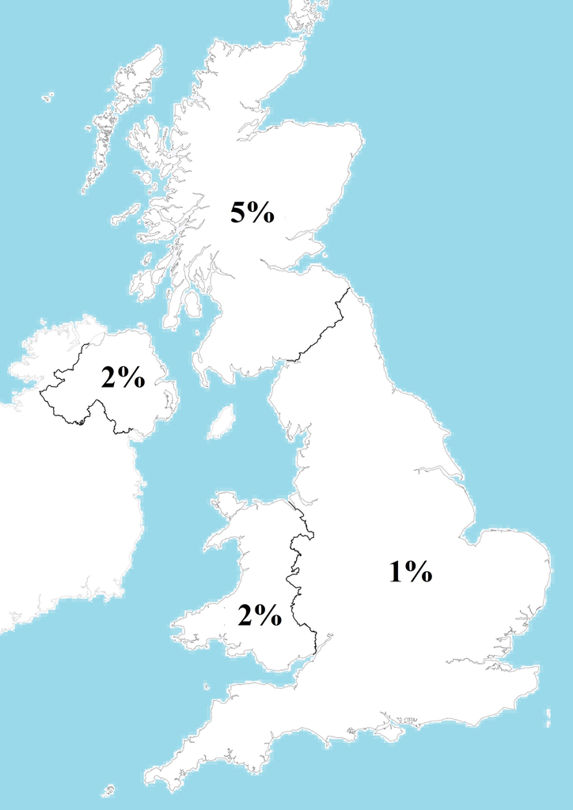

Figure 1.2: Prevalence of the disease in England, Scotland, Wales, and Northern Ireland ($1\%$, $5\%$, $2\%$ and $2\%$, respectively).

We ask two questions:

1. What is the overall prevalence in the UK?
2. What proportion of individuals with the disease are Scottish?

To rephrase these questions in the language of probability, we consider an **experiment** where we randomly select a person from the UK, in such a way that each person is equally likely to be selected. Our questions become:

1. What is the probability this person will have the disease?
2. If we see that they have the disease, then what is the probability they are from Scotland?

### 1.3.1 Basic definitions

We have rephrased our questions in terms of a random experiment. But what do we mean by “equally likely”? If the size of the UK population is $N$, then we have $N$ possible outcomes for our experiment ($N$ people who could be selected). “Equally likely” means that if we could (hypothetically) repeat our experiment infinitely many times, no outcome would occur more or less frequently than any other. In other words, we might say that

$${\mathsf P}(\{\omega\}) = \frac{1}{N} %\quad \text{for each } i = 1, \ldots, N$$
is the **probability** of each possible outcome $\omega$ (for us, $\omega$ would be a person in the UK population). But we need to go further than this. We need define probabilities more generally, so that we can apply them in situations where outcomes might not be equally likely or where there are infinitely many possible outcomes.

**Definition 1.1** A **sample space** (usually denoted $\Omega$) is the set of all possible outcomes of an experiment. An **event** is a set of possible outcomes (a subset of $\Omega$).

In our example, $\Omega$ is the UK population. We can define events $E$, $S$, $W$ and $I$ be the populations of England, Scotland, Wales and Northern Ireland, respectively.

**Definition 1.2** Let $A$ and $B$ be events. We can define further events via set operations:

- The **complement**, $A^c$, is set of outcomes not in $A$.
- The **intersection**, $A \cap B$, is the set of outcomes in both $A$ and $B$.
- The **union**, $A \cup B$, is the set of outcomes in $A$ or $B$ (possibly both).
- The **difference**, $A\setminus B$, is the set of outcomes in $A$ and not in $B$.

Let’s describe the following events in plain English.

- $\Omega$ means “from the UK”.
- $S$ means “from Scotland”.
- $E \cap S$ means “from England and from Scotland” (which is just an empty set).
- $E \cup S$ means “from England or from Scotland”.
- $S^c$ means “from the UK and not from Scotland”.
- $\Omega \setminus S$ means “from the UK and not from Scotland”.
- $\Omega \cap S^c$ means “from the UK and not from Scotland”.
- $E \cup S \cup W \cup I$ means “from England or Scotland or Wales or Northern Ireland”.

No two of the events $E$, $S$, $W$ and $I$ can occur simultaneously, so we say that these four events are mutually exclusive. Their union is the full sample space, forming a partition:
$$\Omega = E \cup S \cup W \cup I.$$

**Definition 1.3** Let $B_{1}, B_{2}, \ldots, B_{k}$ be events. If $B_{i} \cap B_{j}$ is empty (contains no outcomes) for every pair of events ($i \neq j$), we say these $k$ events are **mutually exclusive** (some textbooks use the terms **disjoint** or **mutually incompatible** instead).

**Notation.** For the union of many events or sets, $B_1 \cup B_2 \cup \ldots \cup B_k$, we sometimes write $\bigcup_{i=1}^{k}B_{i}$.

**Definition 1.4** Let $B_{1}, B_{2}, \ldots, B_{k}$ be mutually exclusive. If
$$\bigcup_{i=1}^{k}B_{i} = \Omega$$
then these $k$ events are a **partition** of $\Omega$.

In other words, events are mutually exclusive if they don’t overlap. They are a partition if they don’t overlap and, when combined, they include every possible outcome.

**Definition 1.5** Given a sample space $\Omega$, consider a function
$$B \mapsto {\mathsf P}(B)$$
that maps every event $B$ to a number ${\mathsf P}(B) \in [0,1]$. Suppose that ${\mathsf P}$ satisfies two axioms: ${\mathsf P}(\Omega) = 1$ and
$${\mathsf P}\left(B_1\cup B_2 \cup B_3\cup\ldots\right) = {\mathsf P}(B_1) + {\mathsf P}(B_2) + {\mathsf P}(B_3) + \cdots$$
whenever $B_{1}, B_{2}, B_{3}, \ldots$ are mutually exclusive. Then we can call ${\mathsf P}(B)$ the **probability** of each event $B \subset \Omega$.

The truth is that we will rarely use this definition directly. We just think of ${\mathsf P}$ as a way to assign to any event a number between $0$ and $1$ that describes how likely that event is. The bigger the number, the more likely the event. The two axioms in the definition just mean that:

- $\Omega$ must have probability $100\%$, since it contains all possible outcomes.
- The probability of any union of non-overlapping events is just the sum of their individual probabilities.

When phrased like this, these axioms seem less intimidating and just fit with our intuitive understanding of how probabilities should work. In practice, rather than using the definition, we use the consequences listed below.

**Theorem 1.1** For any events $A$ and $B$, we have:
$$\begin{eqnarray*}
{\mathsf P}(A^{c}) & = & 1-{\mathsf P}(A),\\
{\mathsf P}(A\cup B) & = & {\mathsf P}(A) + {\mathsf P}(B) - {\mathsf P}(A\cap B),\\
{\mathsf P}(A\setminus B) & = & {\mathsf P}(A)-{\mathsf P}(A \cap B).
\end{eqnarray*}$$

Based on Figure 1.1, if each person in the UK is equally likely to be selected then our ${\mathsf P}$ should have:
$$\begin{eqnarray*}
{\mathsf P}(E) = 0.84, \;
{\mathsf P}(W) = 0.05, \;
{\mathsf P}(S) = 0.08, \;
{\mathsf P}(I) = 0.03.
\end{eqnarray*}$$
Consistent with the axioms,
$${\mathsf P}(\Omega) = {\mathsf P}(E\cup S \cup W \cup I) = {\mathsf P}(E) + {\mathsf P}(S) + {\mathsf P}(W) + {\mathsf P}(I) = 1.$$
From the theorem it follows that, for example,
$${\mathsf P}(E \cup S) = {\mathsf P}(E) + {\mathsf P}(S) - {\mathsf P}(E \cap S) = 0.84 + 0.08 - 0 = 0.92$$
and
$${\mathsf P}(E^c) = 1 - {\mathsf P}(E) = 1-0.84 = 0.16.$$
Thus, there is a $92\%$ probability of selecting someone from England or Scotland, and a $16\%$ probability of selecting someone not from England. We can even combine the rules from the theorem to see that
$${\mathsf P}\left((E \cup S)^c\right) = 1 - {\mathsf P}(E \cup S) = 1 - 0.92 = 0.08,$$
so there is only an $8\%$ chance of selecting someone not from England or Scotland.

### 1.3.2 Conditional probability

Let $D$ be the set of individuals in the UK who have the disease. Then ${\mathsf P}(D)$ can be thought of as the prevalence. Can we use Figure 1.2 to immediately write down ${\mathsf P}(D)$? No, because Figure 1.2 actually gives us conditional probabilities. For example, $5\%$ is the probability of a random person having the disease **given** that they are from Scotland.

**Definition 1.6** The **conditional probability of** $A$ **given** $B$ is[^1]
$$\begin{equation*}
{\mathsf P}(A\mid B) =\frac{{\mathsf P}(A\cap B)}{{\mathsf P}(B) }.
\end{equation*}$$

All rules for probabilities also hold for conditional probabilities. Therefore we can handle unions, intersections and complements for conditional probabilities just as we would for probabilities. For example, the probability of someone not having the disease given that they are from Scotland would be
$${\mathsf P}(D^c{}\mid S) = 1 - {\mathsf P}(D\mid S) = 1 - 0.05 = 0.95.$$
Since ${\mathsf P}(S) = 0.08$, the definition allows us to calculate the proportion of the UK population who are both Scottish and have the disease
$$\begin{equation}
{\mathsf P}(D\cap S) = {\mathsf P}(D \mid S){\mathsf P}(S) = 0.05 \times 0.08 = 0.004.\nonumber
\end{equation}$$

To answer question 1, we need ${\mathsf P}(D)$. But we only know the conditional probabilities:
$$\begin{eqnarray*}
{\mathsf P}(D\mid E) = 0.01, \;
{\mathsf P}(D\mid S) = 0.05, \;
{\mathsf P}(D\mid W) = 0.02, \;
{\mathsf P}(D\mid I) = 0.02.
\end{eqnarray*}$$

Since $E$, $S$, $W$ and $I$ form a partition, it might make intuitive sense to write
$$\begin{eqnarray}
{\mathsf P}(D) & = & {\mathsf P}(D\cap E) + {\mathsf P}(D \cap S) + {\mathsf P}(D \cap W) + {\mathsf P}(D \cap I)\\[5pt]
& = & {\mathsf P}(D\mid E)\, {\mathsf P}(E) + {\mathsf P}(D\mid S)\, {\mathsf P}(S) + {\mathsf P}(D\mid W)\, {\mathsf P}(W) + {\mathsf P}(D\mid I)\, {\mathsf P}(I)
\end{eqnarray}$$
since every outcome in $D$ must be in either $D\cap E$ or $D\cap S$ or $D\cap W$ or $D\cap I$.

**Theorem 1.2 (partition theorem)** Let $B_{1}, B_{2}, \ldots, B_{k}$ be a partition. Then, for any event $A$,
$$\begin{equation*}
{\mathsf P}(A) =\sum_{i=1}^{k}{\mathsf P}(A\mid B_{i}){\mathsf P}(B_{i})
\end{equation*}$$
This also applies when the partition consists of infinitely many events, $B_1, B_2, \ldots$ (just replace $k$ with $\infty$ in the sum). The partition theorem is sometimes called the **law of total probability**.

In general, we usually apply the partition theorem when we want the probability of an event but only have conditional probabilities for that event. Our previous equation is just an example of this theorem, where we set $B_{1}=E$, $B_{2}=S$, $B_{3}=W$, $B_{4}=I$ and $A = D$ to get
$$\begin{eqnarray}
{\mathsf P}(D) & = &\sum_{i=1}^{4}{\mathsf P}(D\mid B_{i}){\mathsf P}(B_{i})\\
& = & {\mathsf P}(D\mid E) {\mathsf P}(E) + {\mathsf P}(D\mid S) {\mathsf P}(S) + {\mathsf P}(D\mid W) {\mathsf P}(W) + {\mathsf P}(D\mid I) {\mathsf P}(I)\\
& = & 0.01 \times 0.84 + 0.05 \times 0.08 + 0.02\times 0.05 + 0.02 \times 0.03\\
& = & 0.014.
\end{eqnarray}$$
This answers question 1: overall prevalence in the UK is $1.4\%$.

### 1.3.3 Bayes’ theorem

To answer question 2, we apply the definition of conditional probability to write ${\mathsf P}(S\mid D)$ in terms of ${\mathsf P}(D\mid S)$:
$$\begin{eqnarray*}
{\mathsf P}(S \mid D) & = & \frac{{\mathsf P}(S \cap D)}{{\mathsf P}(D)}\\
& = & \frac{{\mathsf P}(D \mid S){\mathsf P}(S)}{{\mathsf P}(D)}\\ & = & \frac{0.05\times 0.08}{0.014} \approx 0.3,
\end{eqnarray*}$$
which tells us that around $30\%$ of people with the disease are Scottish. This calculation is an example of Bayes’ theorem.

**Theorem 1.3 (Bayes’ theorem)** Let $B_{1}, B_{2}, \ldots, B_{k}$ be a partition of $\Omega$, then[^2]
$$\begin{equation*}
{\mathsf P}(B_{i} \mid A) = \frac{{\mathsf P}(A \mid B_i){\mathsf P}(B_{i})}{{\mathsf P}(A)} = \frac{{\mathsf P}(A\mid B_i){\mathsf P}(B_{i})}{\sum_{j=1}^{k}{\mathsf P}(A\mid B_{j}) {\mathsf P}(B_{j})}
\end{equation*}$$
for any event $A$ with ${\mathsf P}(A) > 0$.

Our answer to question 2 tells us that someone’s probability of having the disease is **not** independent of where they come from.

**Definition 1.7** Events $A$ and $B$ are **independent** if and only if ${\mathsf P}(A\cap B) = {\mathsf P}(A){\mathsf P}(B)$.

Independence is equivalent to ${\mathsf P}(A\mid B) ={\mathsf P}(A)$ and ${\mathsf P}(B\mid A) = {\mathsf P}(B)$. In other words, learning that event $B$ occurred does not change our beliefs about how likely event $A$ is (and vice versa). We can extend this idea to any number of events:

**Definition 1.8** Consider a finite collection of events. These events are **mutually independent** if and only if
$${\mathsf P}(B_{1}\cap B_{2} \cap \ldots \cap B_{j}) = {\mathsf P}(B_{1}){\mathsf P}(B_{2})\ldots{\mathsf P}(B_{j})$$
whenever $B_{1}, B_{2}, \ldots, B_{j}$ are distinct events from this collection.

## 1.4 Statistical models

Now that we understand probability, we can discuss how random quantities can be modelled using probability distributions. This subsection will be a preview of the ideas that we will discuss in more depth over the next ten weeks.

**Example 1.2 (hospital stay)** After surgery, patients can spend days or weeks in hospital. Duration of hospital stay ($X$) varies from patient to patient. We can think of it as a function that assigns a real number (days in hospital) to each element of a sample space (each patient in some population),
$$X : \Omega \rightarrow \mathbb{R}.$$

Let’s consider the next person to undergo surgery as a random member of the patient population. We don’t know how long they will spend in hospital, so $X$ can be thought of as a **random variable**. Then, for example, how might we calculate the probability
$${\mathsf P}(X \in [20, 40])$$
that their stay will be between $20$ and $40$ days long?[^3]

### 1.4.1 Probability distributions

**Definition 1.9** A **random variable** is a function $X:\Omega \rightarrow \mathbb{R}$ defined on a sample space $\Omega$. The **distribution** of $X$ is the collection of all probabilities of the form ${\mathsf P}(X \in C)$ for sets $C \subset \mathbb{R}$.

To obtain the distribution of hospital stay, it seems that we need to write down every ${\mathsf P}(X \in [a, b])$. But there are infinitely many intervals $[a,b]$. So how can we ever hope to specify this distribution fully? Instead of writing down every probability, we try to write down a **statistical model** for $X$ from which we can calculate any ${\mathsf P}(X \in [a,b])$ whenever we need to.

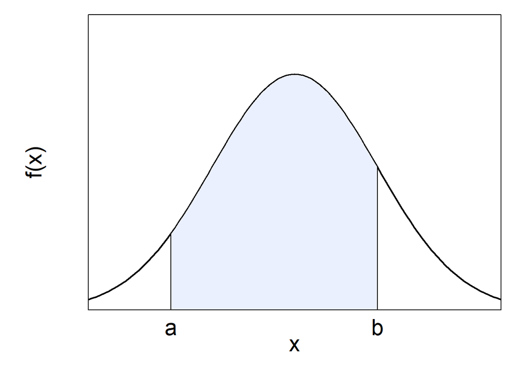

Figure 1.3: The normal distribution curve. The area of the shaded region over the interval $[a, b]$ represents the probability of the event $X \in [a, b]$.

When we think of a statistical model, we often imagine a curve such as the normal distribution’s familiar bell shape. For a normally distributed $X$, the shaded area under the curve in the figure above would be

$${\mathsf P}(X\in [a, b])$$

for any interval $[a, b]$. Along with the rules for probabilities seen in the previous section, the ability to calculate this area allows us to calculate any probability ${\mathsf P}(X\in C)$ that we want. Thus, this fairly simple curve gives us the **entire probability distribution** for $X$.

To calculate these areas, we would need to know the **density function** $f(x)$ that defines the curve. For a normal distribution, this is
$$f(x) =\dfrac{\exp\left[-{\left( x-\mu \right)^{2}/2\sigma^{2}} \right]}{\sqrt{2\pi\sigma^2}}\quad \text{so that} \quad {\mathsf P}(X \in[a,b]) = \int_{a}^{b}f(x)dx,$$
where $\mu$ and $\sigma^2$ are two real numbers called **parameters**.

### 1.4.2 Parameter estimation

Before we can calculate probabilities, we must determine what the parameters should be in our model. The parameters can have a big effect on the properties of our distribution and therefore on the probabilities that we calculate, as seen in Figure 1.4.

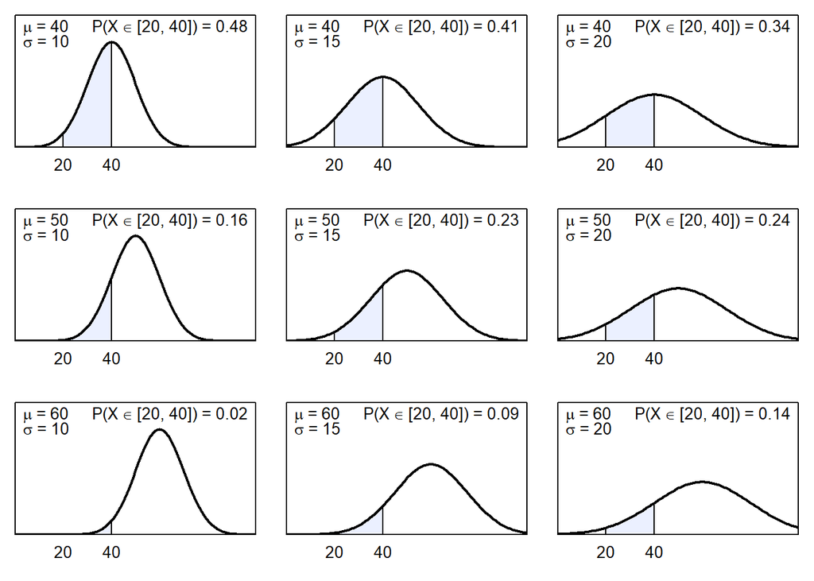

Figure 1.4: The normal distribution curve for different values of $\mu$ and $\sigma^2$.

How can we choose $\mu$ and $\sigma^2$? First we should think about what they represent. In any hypothetical **population** represented by this model, it can be shown that $\mu$ and $\sigma$ are the average and the standard deviation (respectively) of $X$. So, we might try to **estimate** $\mu$ and $\sigma$ by randomly selecting $n$ independent patients from our population, observing their $n$ hospital stays
$$x_{1}, x_{2}, \ldots, x_{n},$$
and then using these to calculate the average and the standard deviation of $X$ **within this sample**. For $\mu$, we would estimate
$$\mu \approx \overline{x} = \frac{x_{1} + x_{2} + \ldots + x_{n}}{n}.$$

But we should remember that each $x_{i}$ is just one observed realisation of a normally distributed random variable $X_{i}$, so our estimate is based on an “IID random sample”.

**Definition 1.10** Random variables $X_{1}, X_{2}, \ldots, X_{n}$ are an **independent and identically distributed (IID) random sample** if they all have the same distribution and
$$X_{1}\in A_1, X_{2}\in A_2, \ldots, X_{n}\in A_n$$
are mutually independent events for all sets $A_1, A_2, \ldots, A_n \subset \mathbb{R}$.

This definition is quite difficult to understand, but it is really just here for completeness. We will assume in this module (as do some textbooks) that all random samples we work with are IID unless explicitly stated otherwise. You will certainly never be asked to show that a collection of random variables are IID using this definition. In practice, the IID property is usually achieved via careful design of our experiment.

**Notation:** We think of a random sample $X_{1}, X_{2}, \ldots, X_{n}$ as a set of random variables, denoted in upper case. Upon observing them, we have $x_{1}, x_{2}, \ldots, x_{n},$ a set of **realisations**, which we think of as fixed numbers, denoted in lower case.[^4]

**Definition 1.11** Let $X_{1}, X_{2}, \ldots, X_{n}$ be a random sample and let $s$ be a real-valued function of $n$ variables. The random variable $S = s(X_{1}, X_{2}, \ldots, X_{n})$ is a **statistic**.

Our estimate, $\overline{x}$, was therefore just a realisation of the statistic

$$\overline{X} = \frac{X_{1} + X_{2} + \ldots + X_{n}}{n}$$

which varies randomly from sample to sample, and could have easily taken a wide range of different values. $\overline{X}$ is itself a random variable. This is why different studies, with the same design and same population, can still produce very different conclusions. So, we should ask:

- Is our estimate likely to be close to the true value of $\mu$?
- After observing our estimate $\overline{x}$, which potential values of $\mu$ are we willing to reject?
- Which are we unable to reject?
- Are there better ways to estimate $\mu$?

These are very important questions because, as we saw in Figure 1.4, if we incorrectly specify $\mu$ (or $\sigma^2$) then this could affect our conclusions about the distribution of $X$. But they are not easy questions. We will spend most of this module gradually developing statistical tools to answer them. These tools will include probability distributions, hypothesis tests, confidence intervals, and various methods of estimation.

[^1]: Of course, we assume in this definition that $P(B) > 0$, otherwise the conditional probability would not be defined. Throughout this module, whenever we work with conditional probabilities, we will assume that the events we condition on have nonzero probability.
[^2]: We don’t really need to memorise these complicated formulae. As long as we know the definition of conditional probability and the partition theorem, Bayes’ theorem follows quite easily.
[^3]: Strictly, we should write the probability ${\mathsf P}(X \in [20, 40])$ as ${\mathsf P}(A)$ where $A$ is the set of all patients whose stay is $20$ to $40$ days,
    $$A = \{\omega\in\Omega \;:\; X(\omega) \in [20, 40]\}.$$
    However, it is common to just write this event more simply as $X \in [20, 40]$. We will use this style from now on.
[^4]: The difference between a realisation $x$ and a random variable $X$ often confuses students who are new to these concepts. It can help to think of of $X$ and $x$ as representing the same quantity before and after it is observed (respectively).  
    For example, let $X$ be the height of the next person you will see today. You don’t necessarily know who this will be (they will be a random person from some population of people), so you don’t know a specific value for $X$. Because there is some randomness in who this person will be, you can think about probabilities for $X$ by thinking of $X$ as a random variable that varies from person to person.  
    However, once you meet this person, you observe their height $x$, which is some fixed number, let’s say $x = 5.5$ feet. This observed value $5.5$ is then something that you **know**, so it is not random. Instead, it is what we call a realisation. It would not make sense to think about probabilities for $x$, because it is just a fixed number.  
    In summary, upper and lower case are used to distinguish between random and non-random quantities. We can use $X$ when we talk about what **might** happen, and we use $x$ when we talk about what actually **did** happen. For example, $X$ is used in planning experiments and $x$ would then represent the actual result of that experiment.